# GermanCredit Prediction

December 27th 2018

## Description of GermanCredit

Data from Dr. Hans Hofmann of the University of Hamburg.

## Details

These data have two classes for the credit worthiness: good or bad. There are predictors related to attributes, such as: checking account status, duration, credit history, purpose of the loan, amount of the loan, savings accounts or bonds, employment duration, Installment rate in percentage of disposable income, personal information, other debtors/guarantors, residence duration, property, age, other installment plans, housing, number of existing credits, job information, Number of people being liable to provide maintenance for, telephone, and foreign worker status.

Many of these predictors are discrete and have been expanded into several 0/1 indicator variables

Source: UCI Machine Learning Repository

## Purpose of the shiny application

The application build some boxplot and print some t.test result which can help to see if the difference means for credit Amount in example is significant for the two class Bad and Good

## The Application show in his first tab, GermanCredit dataset.

GermanCredit data come with caret package:

```r
suppressPackageStartupMessages(library(caret))
data("GermanCredit")
credit <- GermanCredit
head(credit[,1:4],4)
```

```
##   Duration Amount InstallmentRatePercentage ResidenceDuration
## 1        6   1169                         4                 4
## 2       48   5951                         2                 2
## 3       12   2096                         2                 3
## 4       42   7882                         2                 4
```

As you can see in the fisrt tab of Application, we have the ten first row of the data. your can see more rows just by inputing a numeric number in the sidebarpanel in left. After inputing new number please click on "SUBMIT" to view update.

## The code is:

```r
shinyUI(fluidPage(
sidebarLayout(sidebarPanel(
numericInput("num", "number of row to see:", min=1, value = 10)),
    mainPanel(
      tabsetPanel(type = "tabs",
         tabPanel('GermanCredit', h3(textOutput("greeting")), br(),
                           dataTableOutput("Gcredit")))))
shinyServer(function(input, output) {
  output$Gcredit <- renderDataTable({
    head(credit, n=input$num)
})))
```

## in the second tab we plot some box plot like

'boxplot(input$variable~Class, data=GermanCredit)'

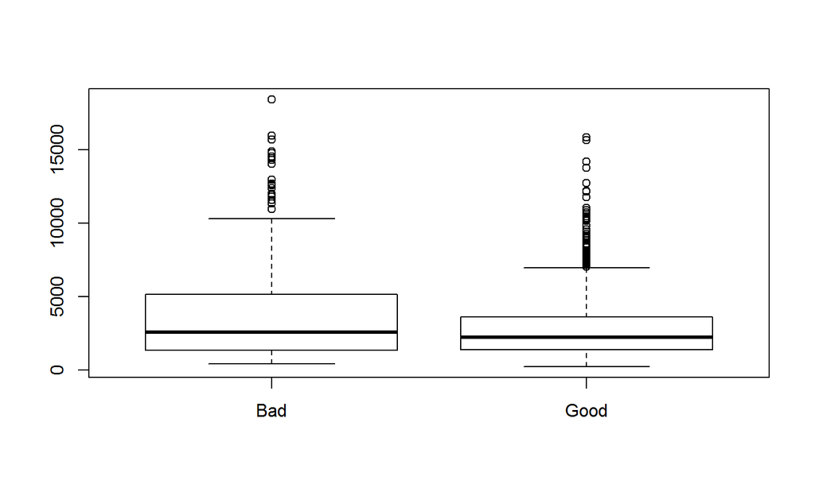

```r
boxplot(Amount~Class, data = credit)
```

## We associate to the plot a result analysis of t.test like:

```r
t.test(GermanCredit$Duration~GermanCredit$Class, var.equal=TRUE)
```

```
##
##  Two Sample t-test
##
## data:  GermanCredit$Duration by GermanCredit$Class
## t = 6.9523, df = 998, p-value = 6.488e-12
## alternative hypothesis: true difference in means is not equal to 0
## 95 percent confidence interval:
##  4.057280 7.248434
## sample estimates:
##  mean in group Bad mean in group Good
##           24.86000           19.20714
```

## Here is the code in ui.R

```r
sidebarLayout(
  sidebarPanel(
    textInput("name","please enter your name","Thibaut"),
    selectInput("variable", "Variable to view:",list("Amount" = "Amount",
                       "Age" = "Age", "Duration" = "Duration"))))
        mainPanel(tabsetPanel(type = "tabs",
         tabPanel("Boxplot", h3(textOutput("caption")), plotOutput("Plot")
                  , verbatimTextOutput('tTest'))))
```

## And in server.R:

```r
shinyServer(function(input, output) {

  # Compute the forumla text in a reactive expression since it is
  # shared by the output$caption and output$Plot expressions
  formulaText <- reactive({
    paste(input$variable, "~ Class")
  })

  # Return the formula text for printing as a caption
  output$caption <- renderText({
    formulaText()
  })
  # Generate a plot of the requested variable against Class and only
  # include outliers if requested
  output$Plot <- renderPlot({
    boxplot(as.formula(formulaText()),
            data = credit,
            outline = input$outliers, frame= FALSE)  })
output$tTest <- renderPrint({
    v <- input$variable
    t.test(credit[credit$Class=="Bad",][[input$variable]],
           credit[credit$Class=="Good",][[input$variable]], var.equal=TRUE)[1:5]
  })
  })
```

## The rest of the Application to perform

We plan to build some technical machine learning to the data and help to predict whether a customer are bad or good!